# Tugas Praktikum 6 & 7 - Diagnostik Model

Muhammad Luthfi Al Gifari

2023-10-16

### Library

```r
library("forecast")
```

```r
library("graphics")
library("TTR")
library("TSA")
library(dplyr)
library(forecast)
library(lmtest)
library(orcutt)
library(HoRM)
library(corrplot)
library(dLagM)
library(dynlm)
library(MLmetrics)
library(ggplot2)
library(tsibble)
library(tseries)
library(MASS)
library(aTSA)
```

# Input Data

```r
Data <- rio::import("https://raw.githubusercontent.com/Mluthfialgifari/Praktikum-MPDW-Sems5/main/microsoft-stock-dataset-Monthly2.csv")
Data
```

```
##          Date  Price
## 1    5/1/2013  32.93
## 2    6/1/2013  34.92
## 3    7/1/2013  34.75
## 4    8/1/2013  32.06
## 5    9/1/2013  31.75
## 6   10/1/2013  33.35
## 7   11/1/2013  35.67
## 8   12/1/2013  38.09
## 9    1/1/2014  37.35
## 10   2/1/2014  37.74
## 11   3/1/2014  37.92
## 12   4/1/2014  41.15
## 13   5/1/2014  40.24
## 14   6/1/2014  40.95
```

[output cut: 106 more lines]

### Mengubah Data: Data Deret Waktu (Time Series)

```r
Data.ts <- ts(Data$Price)
Data.ts
```

```
## Time Series:
## Start = 1
## End = 120
## Frequency = 1
##   [1]  32.93  34.92  34.75  32.06  31.75  33.35  35.67  38.09  37.35  37.74
##  [11]  37.92  41.15  40.24  40.95  41.86  43.21  45.43  46.27  46.89  47.88
##  [21]  46.66  40.59  43.67  40.60  48.58  47.06  44.46  46.98  42.17  44.75
##  [31]  52.85  54.41  54.32  54.88  50.97  55.05  50.00  52.44  51.13  56.60
##  [41]  57.01  57.41  59.97  60.11  62.79  64.36  64.13  65.81  68.68  70.24
##  [51]  69.33  73.10  74.71  74.71  83.68  83.60  86.13  94.79  93.99  90.47
##  [61]  93.21  99.28  98.10 106.03 110.85 114.75 107.05 113.00  99.55 103.78
##  [71] 112.89 118.95 130.53 123.85 136.63 137.00 136.61 139.66 144.26 151.81
##  [81] 158.78 170.43 165.31 153.00 175.80 182.54 203.14 211.52 225.51 213.49
##  [91] 204.29 214.51 222.53 235.06 235.90 238.47 253.40 251.23 269.61 286.36
## [101] 302.87 282.12 331.36 335.13 335.35 310.41 296.40 309.37 277.71 275.20
## [111] 256.39 277.82 258.87 235.41 234.60 253.87 243.08 248.00 250.76 286.52
```

### Membagi Data: Data Latih (80%) dan Data Uji (20%), kemudian dijadikan Time Series

```r
dt.latih <- Data[1:96,2]
dt.latih
```

```
##  [1]  32.93  34.92  34.75  32.06  31.75  33.35  35.67  38.09  37.35  37.74
## [11]  37.92  41.15  40.24  40.95  41.86  43.21  45.43  46.27  46.89  47.88
## [21]  46.66  40.59  43.67  40.60  48.58  47.06  44.46  46.98  42.17  44.75
## [31]  52.85  54.41  54.32  54.88  50.97  55.05  50.00  52.44  51.13  56.60
## [41]  57.01  57.41  59.97  60.11  62.79  64.36  64.13  65.81  68.68  70.24
## [51]  69.33  73.10  74.71  74.71  83.68  83.60  86.13  94.79  93.99  90.47
## [61]  93.21  99.28  98.10 106.03 110.85 114.75 107.05 113.00  99.55 103.78
## [71] 112.89 118.95 130.53 123.85 136.63 137.00 136.61 139.66 144.26 151.81
## [81] 158.78 170.43 165.31 153.00 175.80 182.54 203.14 211.52 225.51 213.49
## [91] 204.29 214.51 222.53 235.06 235.90 238.47
```

```r
dt.uji <- Data[97:120,2]
dt.uji
```

```
##  [1] 253.40 251.23 269.61 286.36 302.87 282.12 331.36 335.13 335.35 310.41
## [11] 296.40 309.37 277.71 275.20 256.39 277.82 258.87 235.41 234.60 253.87
## [21] 243.08 248.00 250.76 286.52
```

```r
dt.latih.ts <- ts(dt.latih, frequency = 12)
dt.latih.ts
```

```
##      Jan    Feb    Mar    Apr    May    Jun    Jul    Aug    Sep    Oct    Nov
## 1  32.93  34.92  34.75  32.06  31.75  33.35  35.67  38.09  37.35  37.74  37.92
## 2  40.24  40.95  41.86  43.21  45.43  46.27  46.89  47.88  46.66  40.59  43.67
## 3  48.58  47.06  44.46  46.98  42.17  44.75  52.85  54.41  54.32  54.88  50.97
## 4  50.00  52.44  51.13  56.60  57.01  57.41  59.97  60.11  62.79  64.36  64.13
## 5  68.68  70.24  69.33  73.10  74.71  74.71  83.68  83.60  86.13  94.79  93.99
## 6  93.21  99.28  98.10 106.03 110.85 114.75 107.05 113.00  99.55 103.78 112.89
## 7 130.53 123.85 136.63 137.00 136.61 139.66 144.26 151.81 158.78 170.43 165.31
## 8 175.80 182.54 203.14 211.52 225.51 213.49 204.29 214.51 222.53 235.06 235.90
##      Dec
## 1  41.15
## 2  40.60
## 3  55.05
## 4  65.81
## 5  90.47
## 6 118.95
## 7 153.00
## 8 238.47
```

```r
dt.uji.ts <- ts(dt.uji, frequency = 12)
dt.uji.ts
```

```
##      Jan    Feb    Mar    Apr    May    Jun    Jul    Aug    Sep    Oct    Nov
## 1 253.40 251.23 269.61 286.36 302.87 282.12 331.36 335.13 335.35 310.41 296.40
## 2 277.71 275.20 256.39 277.82 258.87 235.41 234.60 253.87 243.08 248.00 250.76
##      Dec
## 1 309.37
## 2 286.52
```

# Eksplorasi Data

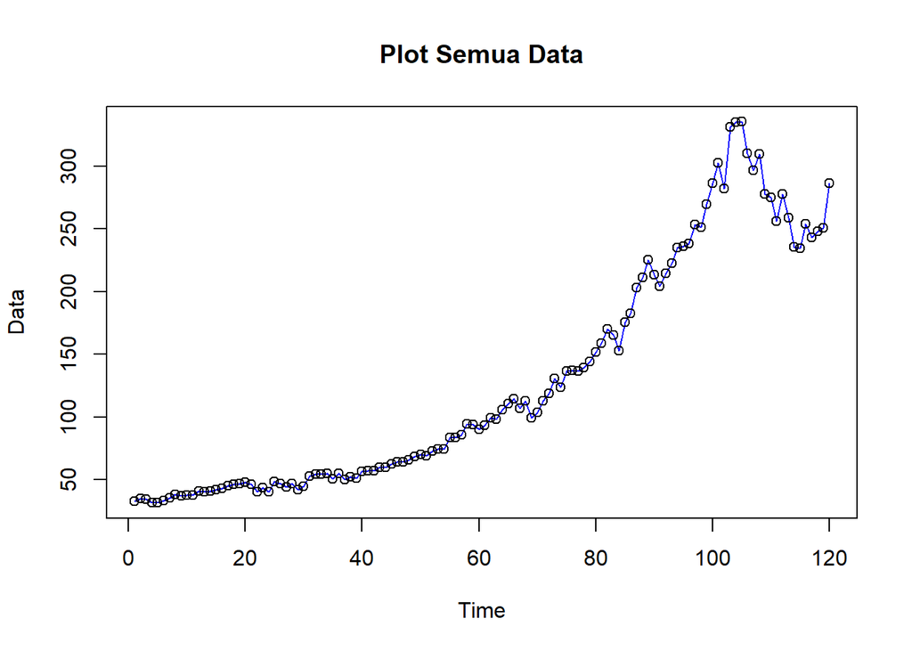

```r
# Semua Data
ts.plot(Data.ts, col = "blue", main = "Plot Semua Data", type = "o", xlab = "Time", ylab = "Data")
points(Data.ts)
```

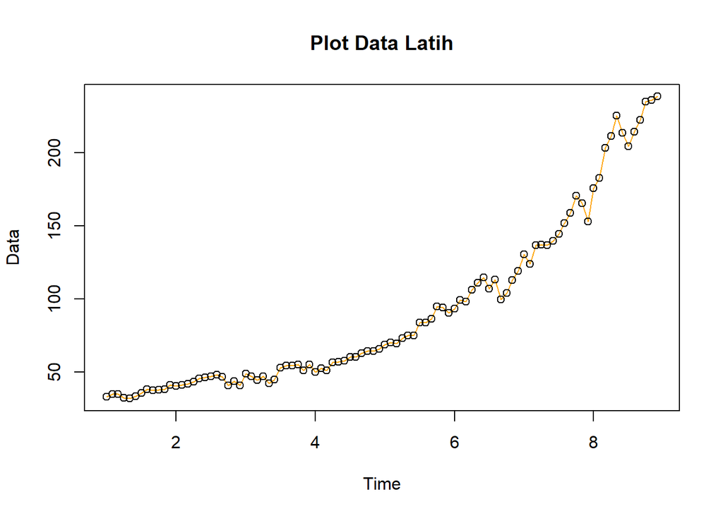

```r
# Data Latih
ts.plot(dt.latih.ts, col = "orange", main = "Plot Data Latih", type = "o", xlab = "Time", ylab = "Data")
points(dt.latih.ts)
```

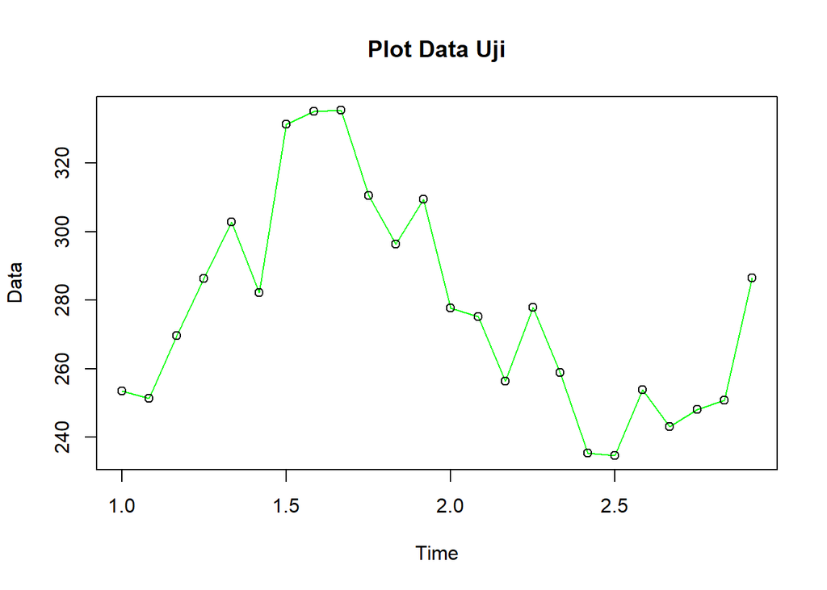

```r
# Data Uji
ts.plot(dt.uji.ts, col = "green", main = "Plot Data Uji", type = "o", xlab = "Time", ylab = "Data")
points(dt.uji.ts)
```

**Interpretasi:** Dapat dilihat bahwa data deret waktu pada data harga saham bulanan Microsoft membentuk pola trend (naik)

# Cek Kestasioneran Data

### Plot ACF

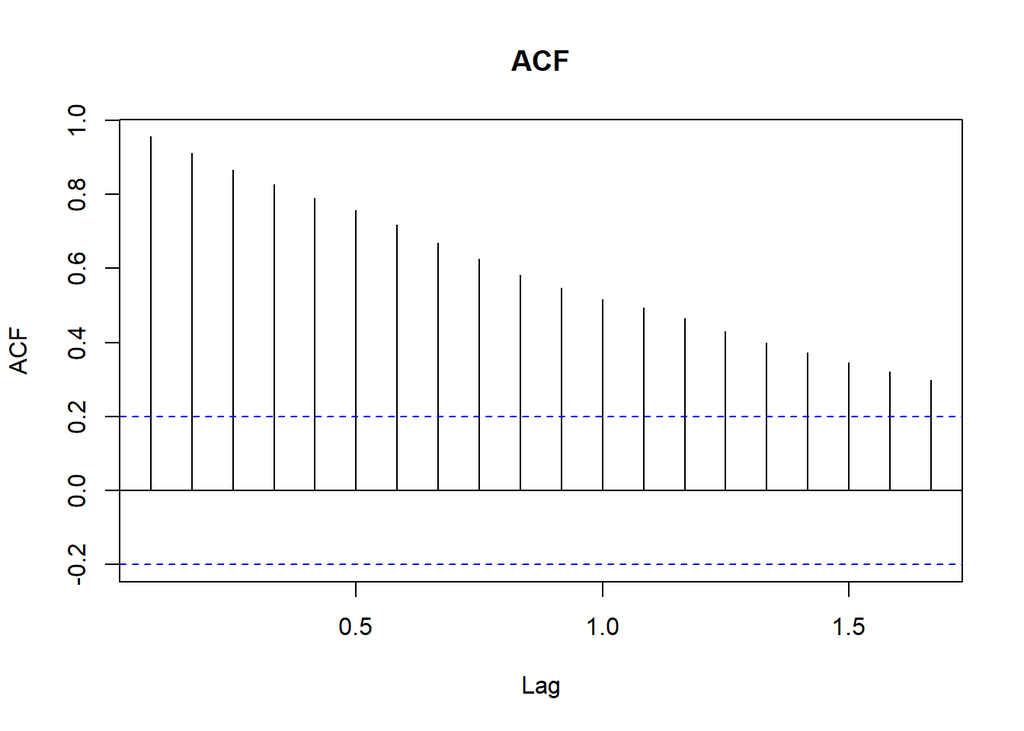

```r
acf(dt.latih.ts, main = "ACF", lag.max = 20)
```

**Interpretasi:** Berdasarkan plot ACF, dapat dilihat bahwa plot ACF pada data tersebut cenderung *tails off* dan tidak membentuk gelombang sinus, menandakan bahwa data tersebut tidak stasioner dalam rataan

### Uji ADF

```r
tseries::adf.test(dt.latih.ts)
```

```
##
##  Augmented Dickey-Fuller Test
##
## data:  dt.latih.ts
## Dickey-Fuller = 1.007, Lag order = 4, p-value = 0.99
## alternative hypothesis: stationary
```

# Pengujian Hipotesis

$H_0$ : Data tidak stasioner dalam rataan $H_1$ : Data stasioner dalam rataan

**Interpretasi:** Berdasarkan uji ADF tersebut, diperoleh *p-value* sebesar 0.99, yang artinya lebih besar dari taraf nyata 5% sehingga tak tolak $H_0$ dan menunjukkan bahwa data tidak stasioner dalam rataan. Hal ini sesuai dengan hasil eksplorasi data menggunakan plot time series dan plot ACF.

### Plot Box-Cox

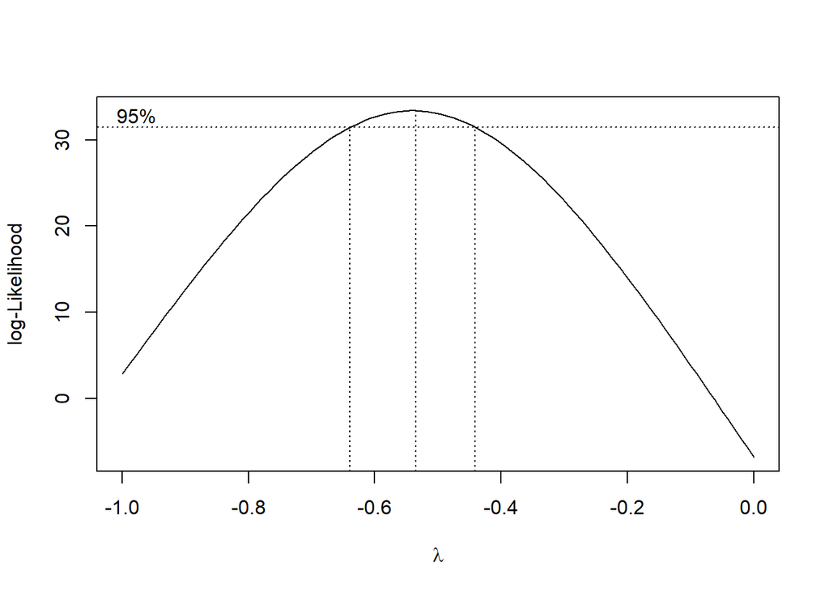

```r
index <- seq(1:96)
bc = boxcox(dt.latih.ts~index, lambda = seq(-1, 0, by = 0.1))
```

```r
# Nilai Rounded Lambda
lambda <- bc$x[which.max(bc$y)]
lambda
```

```
## [1] -0.5353535
```

```r
# Selang Kepercayaan (Confidence Interval)
bc$x[bc$y > max(bc$y) - 1/2 * qchisq(.95,1)]
```

```
##  [1] -0.6363636 -0.6262626 -0.6161616 -0.6060606 -0.5959596 -0.5858586
##  [7] -0.5757576 -0.5656566 -0.5555556 -0.5454545 -0.5353535 -0.5252525
## [13] -0.5151515 -0.5050505 -0.4949495 -0.4848485 -0.4747475 -0.4646465
## [19] -0.4545455 -0.4444444
```

**Interpretasi:** Gambar di atas menunjukkan nilai *rounded value* ($\lambda$) optimum sebesar **-0.535** dan pada selang kepercayaan 95% nilai memiliki batas bawah **-0.636** dan batas atas **-0.444**. Selang tersebut tidak memuat nilai satu, sehingga dapat dikatakan bahwa data bangkitan tidak stasioner dalam ragam.

# Penanganan Ketidakstasioneran Data

```r
# Differencing
train.diff <- diff(dt.latih.ts, differences = 1)
train.diff
```

```
##      Jan    Feb    Mar    Apr    May    Jun    Jul    Aug    Sep    Oct    Nov
## 1          1.99  -0.17  -2.69  -0.31   1.60   2.32   2.42  -0.74   0.39   0.18
## 2  -0.91   0.71   0.91   1.35   2.22   0.84   0.62   0.99  -1.22  -6.07   3.08
## 3   7.98  -1.52  -2.60   2.52  -4.81   2.58   8.10   1.56  -0.09   0.56  -3.91
## 4  -5.05   2.44  -1.31   5.47   0.41   0.40   2.56   0.14   2.68   1.57  -0.23
## 5   2.87   1.56  -0.91   3.77   1.61   0.00   8.97  -0.08   2.53   8.66  -0.80
## 6   2.74   6.07  -1.18   7.93   4.82   3.90  -7.70   5.95 -13.45   4.23   9.11
## 7  11.58  -6.68  12.78   0.37  -0.39   3.05   4.60   7.55   6.97  11.65  -5.12
## 8  22.80   6.74  20.60   8.38  13.99 -12.02  -9.20  10.22   8.02  12.53   0.84
##      Dec
## 1   3.23
## 2  -3.07
## 3   4.08
## 4   1.68
## 5  -3.52
## 6   6.06
## 7 -12.31
## 8   2.57
```

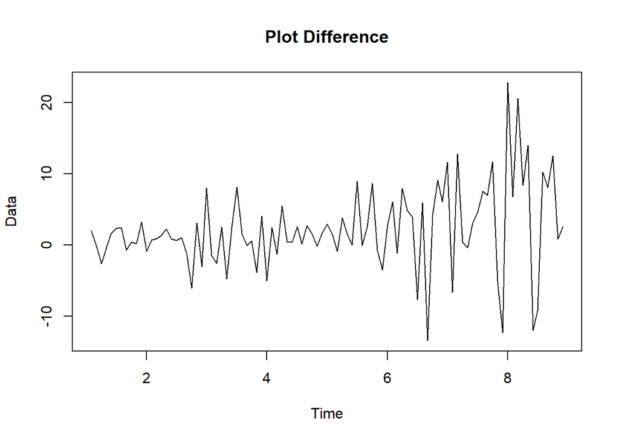

```r
plot.ts(train.diff, lty = 1, xlab = "Time", ylab = "Data", main = "Plot Difference")
```

# Cek Kestasioneran Data (Kembali)

### Plot ACF

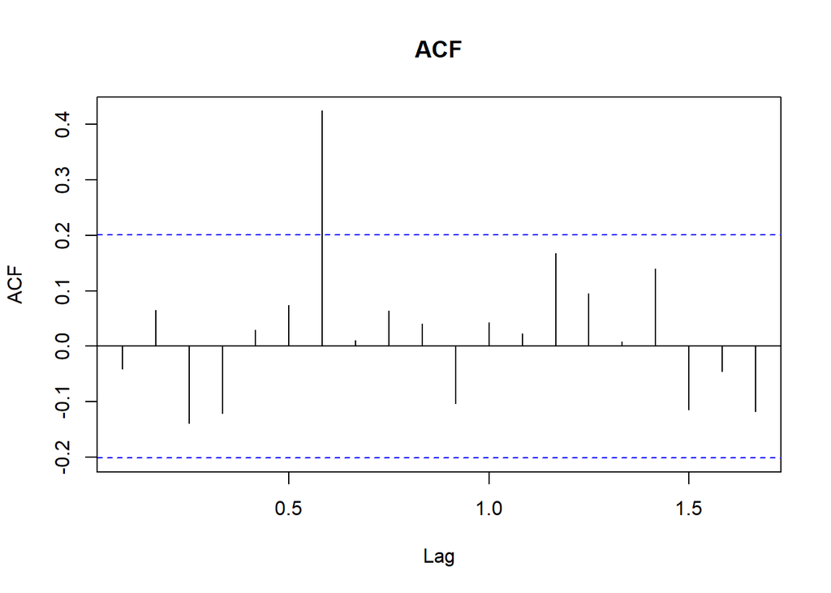

```r
acf(train.diff, main = "ACF", lag.max = 20)
```

### Uji ADF

```r
tseries::adf.test(train.diff)
```

```
##
##  Augmented Dickey-Fuller Test
##
## data:  train.diff
## Dickey-Fuller = -6.7451, Lag order = 4, p-value = 0.01
## alternative hypothesis: stationary
```

**Interpretasi:** Berdasarkan uji ADF kembali, diperoleh *p-value* sebesar 0.01, yang artinya lebih kecil dari taraf nyata 5% sehingga tolak $H_0$ dan menunjukkan bahwa data stasioner dalam rataan. Hal ini sesuai dengan hasil eksplorasi data menggunakan plot time series dan plot ACF (kembali).